# 06 Mapping Introduction

Author

Ben Sunshine

## 2/4/24

## 6.1

```r
## install.packages("maps")
library(maps)
library(tidyverse)
state_df <- ggplot2::map_data("state")
```

```r
# ggplot(data = state_df,
#             mapping = aes(x = long, y = lat,
#                           group = group)) +
#   geom_polygon()
#
# # better:
# ggplot(data = state_df,
#             mapping = aes(x = long, y = lat,
#                           group = group)) +
#   geom_polygon(colour = "black", fill = "white") +
#   coord_map(projection = "albers", lat0 = 39, lat1 = 45) +
#   theme_void()
```

```r
library(usdata)
state_stats
```

```
# A tibble: 51 × 24
   state   abbr   fips pop2010 pop2000 homeownership multiunit income med_income
   <fct>   <fct> <dbl>   <dbl>   <dbl>         <dbl>     <dbl>  <dbl>      <dbl>
 1 Alabama AL        1  4.78e6  4.45e6          71.1      15.5  22984      42081
 2 Alaska  AK        2  7.10e5  6.27e5          64.7      24.6  30726      66521
 3 Arizona AZ        4  6.39e6  5.13e6          67.4      20.7  25680      50448
 4 Arkans… AR        5  2.92e6  2.67e6          67.7      15.2  21274      39267
 5 Califo… CA        6  3.73e7  3.39e7          57.4      30.7  29188      60883
 6 Colora… CO        8  5.03e6  4.30e6          67.6      25.6  30151      56456
 7 Connec… CT        9  3.57e6  3.41e6          69.2      34.6  36775      67740
 8 Delawa… DE       10  8.98e5  7.84e5          73.6      17.7  29007      57599
 9 Distri… DC       11  6.02e5  5.72e5          43.5      61.7  42078      58526
10 Florida FL       12  1.88e7  1.60e7          69.7      30    26551      47661
# ℹ 41 more rows
# ℹ 15 more variables: poverty <dbl>, fed_spend <dbl>, land_area <dbl>,
#   smoke <dbl>, murder <dbl>, robbery <dbl>, agg_assault <dbl>, larceny <dbl>,
#   motor_theft <dbl>, soc_sec <dbl>, nuclear <dbl>, coal <dbl>,
#   tr_deaths <dbl>, tr_deaths_no_alc <dbl>, unempl <dbl>
```

```r
state_stats <- state_stats |> mutate(state = str_to_lower(state))
state_full <- left_join(state_df, state_stats, by = c("region" = "state"))
#
# ggplot(data = state_full, aes(x = long, y = lat, group = group)) +
#   geom_polygon(colour = "black", aes(fill = coal)) +
#   coord_map(projection = "albers", lat0 = 39, lat1 = 45) +
#   theme_void() +
#   scale_fill_viridis_b()
```

Exercise 1: The reading gave one example where the “best” graph to show woud not be a map. Think of a second example where, even though the data is spatial, the best graph to make a particular argument would not be a map.

- When examining unemployment rates by state over a time period, it would be better to layer geom_lines to show the trends over time of unemployment rates. Using just a map plot limits the amount of period information the viewer has.

Exercise 2: Refer back the United States examples that we completed. Choose a variable or two variables where a map makes the most sense to visualize that variable and explain your reasoning. Then, choose a variable or two variables where you might make a plot other than a map and explain your reasoning for why the map makes less sense for this variable.

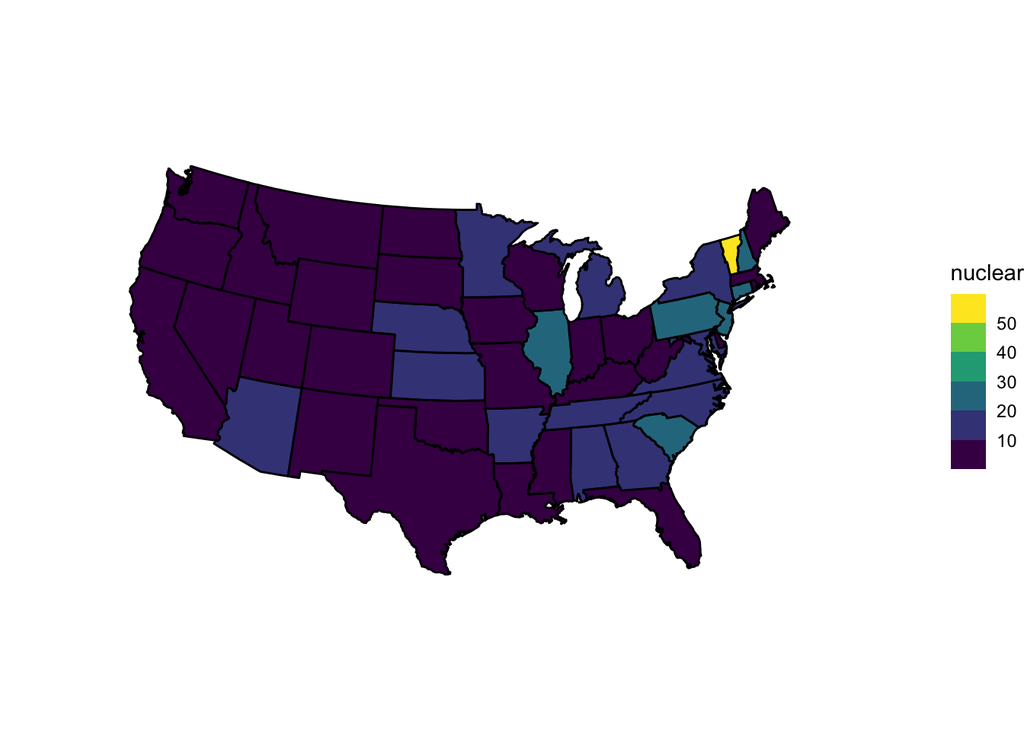

```r
# map plot
ggplot(data = state_full, aes(x = long, y = lat, group = group)) +
  geom_polygon(colour = "black", aes(fill = nuclear)) +
  coord_map(projection = "albers", lat0 = 39, lat1 = 45) +
  theme_void() +
  scale_fill_viridis_b()
```

- Using a map layout makes sense for this plot, because it shows regional trends in nuclear power usage.

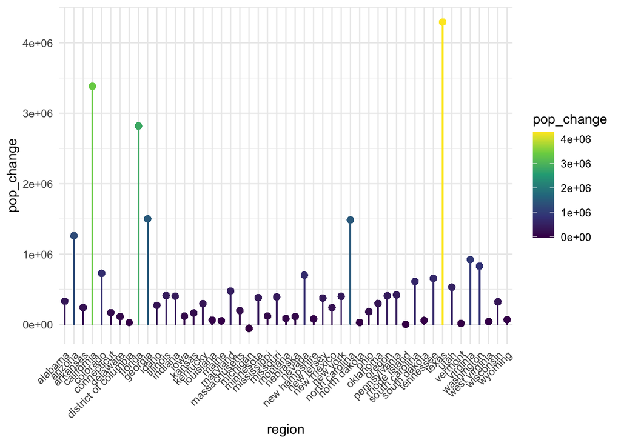

```r
state_full %>%
  mutate(pop_change = pop2010 - pop2000) %>%
  ggplot(aes(x = region, y = pop_change)) +
  geom_segment(aes(x = region, xend = region, y = 0, yend = pop_change, color = pop_change)) +
  geom_point(aes(color = pop_change), size = 2) +
  theme_minimal() +
  theme(axis.text.x = element_text(angle = 45, hjust = 1)) +
  scale_color_viridis_c()
```

- This plot makes more sense, because it shows the actual scale to which population changes due to the fact you can compare the lengths of each segment.

Exercise 3: Which states had the fastest growth rate between 2000 and 2010? Make a variable for the percent change in population and then map this variable.

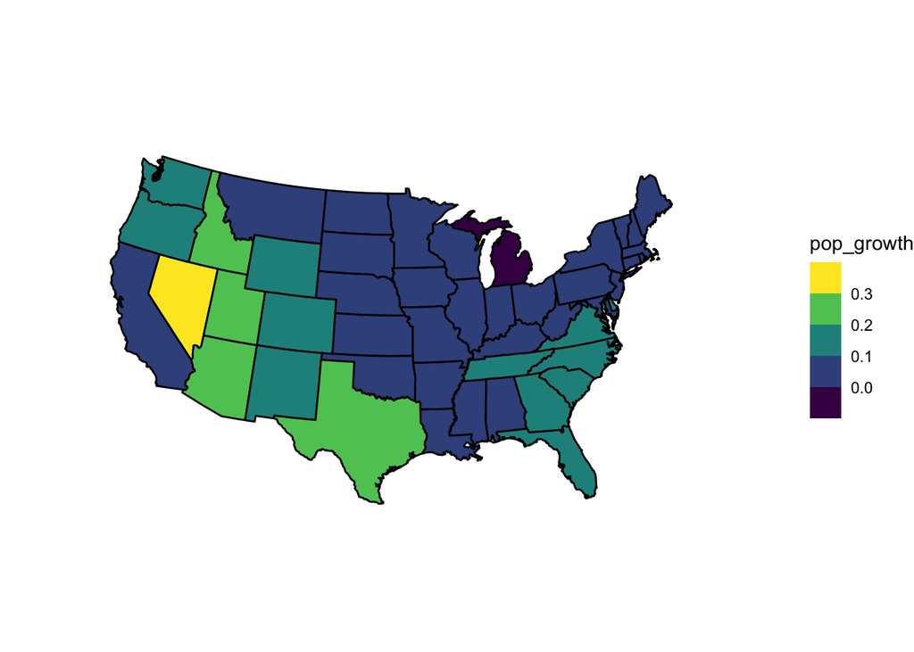

```r
state_full %>%
  mutate(pop_growth = (pop2010-pop2000)/pop2000) %>%
  ggplot(aes(x = long, y = lat, group = group)) +
  geom_polygon(colour = "black", aes(fill = pop_growth)) +
  coord_map(projection = "albers", lat0 = 39, lat1 = 45) +
  theme_void() +
  scale_fill_viridis_b()
```

- Nevada has the fastest growth rate from 2000 to 2010.

Exercise 4: To your map in Exercise 3, think about which type of colour scale makes the most sense to use (sequential, diverging, or unordered). Change the colour scale to match what makes the most sense

.

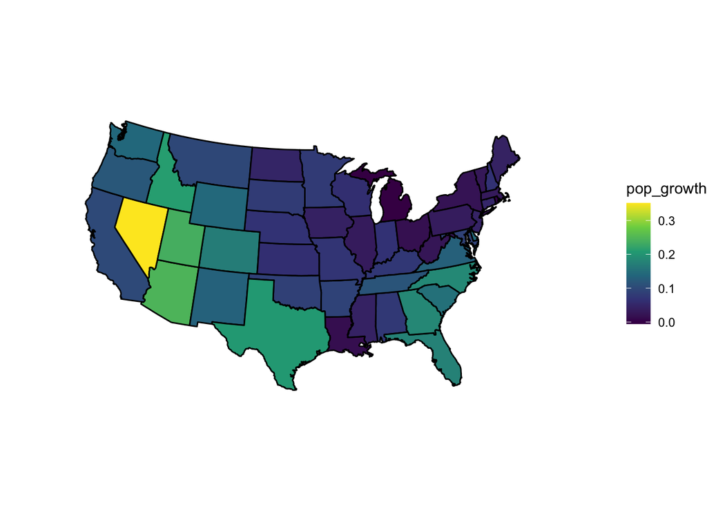

```r
state_full %>%
  mutate(pop_growth = (pop2010-pop2000)/pop2000) %>%
  ggplot(aes(x = long, y = lat, group = group)) +
  geom_polygon(colour = "black", aes(fill = pop_growth)) +
  coord_map(projection = "albers", lat0 = 39, lat1 = 45) +
  theme_void() +
  scale_fill_viridis_c()
```